# HW1

Joshua Ingram

# DUE: Wednesday, September 11th, at 5pm via Canvas Submission.

# Problem #1

Indicate whether each scenario is a classification or regression problem, and how many variables are used to describe an observation.

1. Predicting if a student is going to SAT the college-level introductory statistics course based on their overall high school GPA, their algebra grade and their geometry grade.

Answer: Classification problem with 3 variables used to describe the observation.

2. Same as before, only now predicting the letter grade (A,B,C,D,F).

Answer: Classification problem with 3 variables used to describe the observation.

3. Predicting score differential in a football game between **two opponents**. We assume that it is mid-season, and obtain the data on the games completed by then, studying such variables as: yards (gained & allowed), touchdowns (scored & allowed), turnovers (committed & forced), whether it rains or not.

Answer: Regression problem with 4 variables used to describe the observation.

4. Forecasting the total number of items sold by a Walmart supermarket based on the day of the week, location and store size.

Answer: Regression problem with 3 variables used to describe the observation.

# Problem #2

In data set $cystfibr$ of $ISwR$ package, proceed to:

```r
head(cystfibr)
```

```
##   age sex height weight bmp fev1  rv frc tlc pemax
## 1   7   0    109   13.1  68   32 258 183 137    95
## 2   7   1    112   12.9  65   19 449 245 134    85
## 3   8   0    124   14.1  64   22 441 268 147   100
## 4   8   1    125   16.2  67   41 234 146 124    85
## 5   8   0    127   21.5  93   52 202 131 104    95
## 6   9   0    130   17.5  68   44 308 155 118    80
```

1. Use a looping construct to loop through each variable and calculate mean and standard deviation *without* using $R$’s customized functions like $mean(), sd()$.

Mean and SD

```r
for (var in 1:ncol(cystfibr)){

  name <- colnames(cystfibr[var])
  len <- length(cystfibr[[name]])
  mean <- sum(cystfibr[[name]]) / len

  print(name)
  print(paste("Mean =", mean))

  sum1 <- 0

  for (i in cystfibr[[name]]){

    sum1 <- sum1 + (i - mean)^2

  }

  sd <- sqrt(sum1/(len-1))
  print(paste("Standard Deviation =", sd))

}
```

```
## [1] "age"
## [1] "Mean = 14.48"
## [1] "Standard Deviation = 5.05898540552682"
## [1] "sex"
## [1] "Mean = 0.44"
## [1] "Standard Deviation = 0.506622805119022"
## [1] "height"
## [1] "Mean = 152.8"
## [1] "Standard Deviation = 21.5"
## [1] "weight"
## [1] "Mean = 38.404"
## [1] "Standard Deviation = 17.8981256001851"
## [1] "bmp"
## [1] "Mean = 78.28"
## [1] "Standard Deviation = 12.0052766176655"
## [1] "fev1"
## [1] "Mean = 34.72"
## [1] "Standard Deviation = 11.1971722620788"
## [1] "rv"
## [1] "Mean = 255.2"
## [1] "Standard Deviation = 86.0169556928555"
## [1] "frc"
## [1] "Mean = 155.4"
## [1] "Standard Deviation = 43.7187983976382"
## [1] "tlc"
## [1] "Mean = 114"
## [1] "Standard Deviation = 16.9681073389658"
## [1] "pemax"
## [1] "Mean = 109.12"
## [1] "Standard Deviation = 33.4369057579595"
```

2. Create a matrix with rows corresponding to variables, columns - to calculated summaries (mean, sd), and fill it out with the results of the previous step accordingly. Please assign appropriate row and column names as well.

```r
matrix1 <- matrix(c("name", "mean", "sd"), ncol = 3)

for (var in 1:ncol(cystfibr)){

  vec <- c()

  name <- colnames(cystfibr[var])
  len <- length(cystfibr[[name]])
  mean <- sum(cystfibr[[name]]) / len

  vec[1] <- name
  vec[2] <- mean

  sum1 <- 0

  for (i in cystfibr[[name]]){

    sum1 <- sum1 + (i - mean)^2

  }

  sd <- sqrt(sum1/(len-1))

  vec[3] <- sd

  matrix1 <- rbind(matrix1, vec)

}

matrix1
```

```
##     [,1]     [,2]     [,3]
##     "name"   "mean"   "sd"
## vec "age"    "14.48"  "5.05898540552682"
## vec "sex"    "0.44"   "0.506622805119022"
## vec "height" "152.8"  "21.5"
## vec "weight" "38.404" "17.8981256001851"
## vec "bmp"    "78.28"  "12.0052766176655"
## vec "fev1"   "34.72"  "11.1971722620788"
## vec "rv"     "255.2"  "86.0169556928555"
## vec "frc"    "155.4"  "43.7187983976382"
## vec "tlc"    "114"    "16.9681073389658"
## vec "pemax"  "109.12" "33.4369057579595"
```

3. Proceed to:
   1. Extract all information on first $10$ observations.

```r
head(cystfibr, 10)
```

```
##    age sex height weight bmp fev1  rv frc tlc pemax
## 1    7   0    109   13.1  68   32 258 183 137    95
## 2    7   1    112   12.9  65   19 449 245 134    85
## 3    8   0    124   14.1  64   22 441 268 147   100
## 4    8   1    125   16.2  67   41 234 146 124    85
## 5    8   0    127   21.5  93   52 202 131 104    95
## 6    9   0    130   17.5  68   44 308 155 118    80
## 7   11   1    139   30.7  89   28 305 179 119    65
## 8   12   1    150   28.4  69   18 369 198 103   110
## 9   12   0    146   25.1  67   24 312 194 128    70
## 10  13   1    155   31.5  68   23 413 225 136    95
```

```
b. Extract all information on observations $\# 5,10 \ \& \ 15$.
```

```r
cystfibr[c(5, 10, 15),]
```

```
##    age sex height weight bmp fev1  rv frc tlc pemax
## 5    8   0    127   21.5  93   52 202 131 104    95
## 10  13   1    155   31.5  68   23 413 225 136    95
## 15  16   1    160   35.9  66   31 302 133 101   134
```

```
c. Extract all information on last $10$ observations.
```

```r
tail(cystfibr, 10)
```

```
##    age sex height weight bmp fev1  rv frc tlc pemax
## 16  17   1    153   34.8  70   29 204 118 120   134
## 17  17   0    174   44.7  70   49 187 104 103   165
## 18  17   1    176   60.1  92   29 188 129 130   120
## 19  17   0    171   42.6  69   38 172 130 103   130
## 20  19   1    156   37.2  72   21 216 119  81    85
## 21  19   0    174   54.6  86   37 184 118 101    85
## 22  20   0    178   64.0  86   34 225 148 135   160
## 23  23   0    180   73.8  97   57 171 108  98   165
## 24  23   0    175   51.1  71   33 224 131 113    95
## 25  23   0    179   71.5  95   52 225 127 101   195
```

```
d. Extract all information on the first *variable*.
```

```r
cystfibr[,1]
```

```
##  [1]  7  7  8  8  8  9 11 12 12 13 13 14 14 15 16 17 17 17 17 19 19 20 23
## [24] 23 23
```

```
e. Extract information on the first *variable* for observations $\# 5,10,15$.
```

```r
cystfibr[c(5, 10, 15), 1]
```

```
## [1]  8 13 16
```

```
f. Extract all information on the patients of above-average height.
```

```r
hmean <- mean(cystfibr$height)
subset(cystfibr, height > hmean, select = height)
```

```
##    height
## 10    155
## 11    156
## 12    153
## 13    160
## 14    158
## 15    160
## 16    153
## 17    174
## 18    176
## 19    171
## 20    156
## 21    174
## 22    178
## 23    180
## 24    175
## 25    179
```

4. Show all the information on 5 oldest patients.

```r
cystfibr[tail(order(cystfibr$age), 5),]
```

```
##    age sex height weight bmp fev1  rv frc tlc pemax
## 21  19   0    174   54.6  86   37 184 118 101    85
## 22  20   0    178   64.0  86   34 225 148 135   160
## 23  23   0    180   73.8  97   57 171 108  98   165
## 24  23   0    175   51.1  71   33 224 131 113    95
## 25  23   0    179   71.5  95   52 225 127 101   195
```

5. Using a $subset()$ function, only select the observations that have above-average values for both $weight$ and $height$.

```r
subset(cystfibr, weight > mean(cystfibr$weight) & height > mean(cystfibr$height))
```

```
##    age sex height weight bmp fev1  rv frc tlc pemax
## 11  13   0    156   39.9  89   39 206 142  95   110
## 12  14   1    153   42.1  90   26 253 191 121    90
## 13  14   0    160   45.6  93   45 174 139 108   100
## 14  15   1    158   51.2  93   45 158 124  90    80
## 17  17   0    174   44.7  70   49 187 104 103   165
## 18  17   1    176   60.1  92   29 188 129 130   120
## 19  17   0    171   42.6  69   38 172 130 103   130
## 21  19   0    174   54.6  86   37 184 118 101    85
## 22  20   0    178   64.0  86   34 225 148 135   160
## 23  23   0    180   73.8  97   57 171 108  98   165
## 24  23   0    175   51.1  71   33 224 131 113    95
## 25  23   0    179   71.5  95   52 225 127 101   195
```

6. Make a scatterplot for an arbitrary pair of quantitative variables, comment on the relationship.

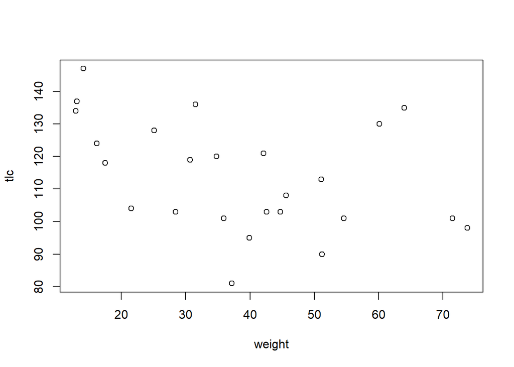

```r
plot(tlc ~ weight, data = cystfibr)
```

Plotting weight and total lung capacity, with TLC as the response, there may be a slightly noticeable relationship, with tlc decreasing as weight increases. However, it may not be a very strong relationship.

# Problem #3

Define your own function in $R$ and demonstrate its functionality:

1. Function needs to contain:
   1. at least one assignment operation (‘<-’)
   2. at least one $required$ argument (without a default value)
   3. at least one argument with a default value
   4. at least one conditional $if$-expression
2. Demonstrate:
   1. 3 calls to show that function works properly on various $required$ inputs}
   2. a call in which you specify a non-default value

Function idea examples: check if a string/sequence has a certain property, or make a cyclic algebraic calculation, or provide various plots for inputted sequence/data…

**Example**: Function $is.increasing()$ allows to check if a sequence of numbers is monotonically increasing (returns TRUE) or not (returns FALSE). Upon user’s request, it can also print out the consecutive differences.

```r
is.increasing <- function(x,printout=FALSE){
  n <- length(x)
  dif.vec <- x[2:n]-x[1:(n-1)]
  if (printout == TRUE) print(dif.vec)
  if (sum(dif.vec<=0) != 0) return(F)  # Important note: function stops after executing the
  return(T)                            # first 'return' statement it gets to
}

x <- c(1:10)
is.increasing(x)
```

```
## [1] TRUE
```

```r
y <- c(5,5,5)
is.increasing(y)
```

```
## [1] FALSE
```

```r
z <- c(1,5,3,7,9)
is.increasing(z)
```

```
## [1] FALSE
```

```r
is.increasing(z,printout=T)   # The call where you specify the non-default value
```

```
## [1]  4 -2  4  2
```

```
## [1] FALSE
```

My Function (gives the user the mean and/or standard deviation of a vector of numbers… func = 1 gives mean, func = 2 gives sd, func = 3 gives both sd and mean):

```r
sd.mean <- function(vector, func = 3){
    length <- length(vector)
    mean <- sum(vector)/length

    sum <- 0

    for (i in vector){
      sum <- sum + (i - mean)^2
    }

    sd <- sqrt(sum/(length-1))

  if (func == 1) print(paste("Mean =", mean))

  if (func == 2) print(paste("Standard Deviation =", sd))

  if (func == 3) print(paste("Mean =", mean, "Standard Deviation =", sd))

}

sd.mean(c(1,4,5,6,12,9))
```

```
## [1] "Mean = 6.16666666666667 Standard Deviation = 3.86867763798777"
```

```r
sd.mean(c(93,123,45,199,33,55))
```

```
## [1] "Mean = 91.3333333333333 Standard Deviation = 62.397649528381"
```

```r
sd.mean(c(55,66,223,44,6,22))
```

```
## [1] "Mean = 69.3333333333333 Standard Deviation = 78.3879242400682"
```

```r
sd.mean(c(1,2,4,6,2,7,8), func = 1)
```

```
## [1] "Mean = 4.28571428571429"
```

# Problem #4

Count the total number of boys in data set $juul$ (from package $ISwR$), who have insulin-like growth factor greater than 400, in three different ways (make sure the output is the same though):

```r
head(juul, 15)
```

```
##     age menarche sex igf1 tanner testvol
## 1    NA       NA  NA   90     NA      NA
## 2    NA       NA  NA   88     NA      NA
## 3    NA       NA  NA  164     NA      NA
## 4    NA       NA  NA  166     NA      NA
## 5    NA       NA  NA  131     NA      NA
## 6  0.17       NA   1  101      1      NA
## 7  0.17       NA   1   97      1      NA
## 8  0.17       NA   1  106      1      NA
## 9  0.17       NA   1  111      1      NA
## 10 0.17       NA   1   79      1      NA
## 11 0.17       NA   1   43      1      NA
## 12 0.17       NA   1   64      1      NA
## 13 0.25       NA   1   90      1      NA
## 14 0.25       NA   1  141      1      NA
## 15 0.42       NA   1   42      1      NA
```

- Using for-loop

```r
count <- 0

for (i in 1:nrow(juul)){
  if (juul$sex[i] == 1 & is.na(juul$sex[i]) != TRUE) {
    if (juul$igf1[i] > 400 & is.na(juul$igf1[i]) != TRUE){
      count = count + 1
    }
  }
}

print(count)
```

```
## [1] 144
```

- Using vectorized operations (can be done in one line)

```r
length(which(juul$igf1 > 400 & juul$sex == 1))
```

```
## [1] 144
```

- Using data frame subsetting (can be done in one line)

```r
nrow(juul[juul$sex == 1 & is.na(juul$sex) != TRUE & is.na(juul$igf1) != TRUE & juul$igf1 > 400,])
```

```
## [1] 144
```